# SLBP analysis

Thomas Schwarzl, Sudeep Sahadevan and Thileepan Sekaran

3/12/2021

# 1 SLBP analysis

This markdown file contains the complete analysis of SLBP example dataset and follows the same analysis steps and file naming patterns as it is described in the chapter.

## 1.1 Installation of DEWSeq and setup

```r
if(!requireNamespace("BiocManager", quietly = TRUE))
    install.packages("BiocManager")
BiocManager::install("DEWSeq")
```

## 1.2 Load libraries

```r
suppressPackageStartupMessages(require(DEWSeq))
suppressPackageStartupMessages(require(IHW))
suppressPackageStartupMessages(require(tidyverse))
suppressPackageStartupMessages(require(data.table))
suppressPackageStartupMessages(require(ggplot2))
suppressPackageStartupMessages(require(ggrepel))
```

`suppressPackageStartupMessages` ignores all start up messages

## 1.3 Data import

```r
setwd('/path/to/SLBP_analysis')
```

```r
count_matrix <- fread('counts/SLBP_K562_w50s20_counts.txt.gz',
                      stringsAsFactors=FALSE, sep="\t", header=TRUE)
count_matrix <- column_to_rownames(count_matrix,'unique_id')
head(count_matrix)
```

```
##                                    ENCFF218ZEI ENCFF511HSJ ENCFF879UID
## ENSG00000227232.5:intron0008W00093           1           0           0
## ENSG00000227232.5:intron0008W00094           1           0           0
## ENSG00000268903.1:exon0001W00003             1           0           2
## ENSG00000268903.1:exon0001W00004             3           0           2
## ENSG00000268903.1:exon0001W00005             3           0           2
## ENSG00000268903.1:exon0001W00006             2           0           0
```

```r
col_data <- data.frame(type=c('IP','IP','SMI'),
                       row.names=colnames(count_matrix))
head(col_data)
```

```
##             type
## ENCFF218ZEI   IP
## ENCFF511HSJ   IP
## ENCFF879UID  SMI
```

```r
annotation_file <- 'annotation/SLBP_K562_w50s20_annotation.txt.gz'
```

### 1.3.1 Create DESeqDataset

```r
ddw <- DESeqDataSetFromSlidingWindows(countData=count_matrix, colData=col_data,
                                      annotObj=annotation_file, design=~type)
head(ddw)
```

```
## class: DESeqDataSet
## dim: 6 3
## metadata(1): version
## assays(1): counts
## rownames(6): ENSG00000225630.1:exon0001W00013
##   ENSG00000225630.1:exon0001W00014 ... ENSG00000225630.1:exon0001W00017
##   ENSG00000225630.1:exon0001W00018
## rowData names(8): unique_id gene_id ... Total_nr_of_region
##   window_number
## colnames(3): ENCFF218ZEI ENCFF511HSJ ENCFF879UID
## colData names(1): type
```

## 1.4 Estimate size factors

```r
ddw <- estimateSizeFactors(ddw)
sizeFactors(ddw)
```

```
## ENCFF218ZEI ENCFF511HSJ ENCFF879UID
##   0.8735805   0.7272363   1.5874011
```

### 1.4.1 Estimate size factors for only protein coding genes

```r
ddw_mRNAs <- ddw[ rowData(ddw)[,"gene_type"] == "protein_coding", ]
ddw_mRNAs <- estimateSizeFactors(ddw_mRNAs)
sizeFactors(ddw) <- sizeFactors(ddw_mRNAs)
```

```r
sizeFactors(ddw_mRNAs)
```

```
## ENCFF218ZEI ENCFF511HSJ ENCFF879UID
##   0.8735805   0.7937005   1.5874011
```

### 1.4.2 Estimate size factors without significant windows

In this context, the aim is to use only the windows that which do not show a large difference between IP and SMI samples for normalization.

This step uses `local` fit for dispersion estimation and Likelihood-ratio test (LRT)

```r
ddw_tmp <- ddw
ddw_tmp <- estimateDispersions(ddw_tmp, fitType = "local", quiet = TRUE)
ddw_tmp <- nbinomLRT(ddw_tmp,full = ~type,reduced = ~1)
tmp_significant_windows <-
                results(ddw_tmp,
                    contrast = c("type", "IP", "SMI"),
                    tidy = TRUE,
                    filterFun = ihw) %>%
                dplyr::filter(padj < 0.05) %>%
                .[["row"]]
rm(ddw_tmp)
```

Now estimate the size factors without the significant windows.

```r
ddw_mRNAs <- ddw_mRNAs[ !rownames(ddw_mRNAs) %in% tmp_significant_windows, ]
ddw_mRNAs <- estimateSizeFactors(ddw_mRNAs)
sizeFactors(ddw) <- sizeFactors(ddw_mRNAs)
```

```r
sizeFactors(ddw_mRNAs)
```

```
## ENCFF218ZEI ENCFF511HSJ ENCFF879UID
##   0.8735805   0.7937005   1.5874011
```

```r
rm(ddw_mRNAs)
```

## 1.5 Prefiltering

```r
keep <- which(rowSums(counts(ddw)>1)>=2)
ddw <- ddw[keep,]
ddw
```

```
## class: DESeqDataSet
## dim: 35601 3
## metadata(1): version
## assays(1): counts
## rownames(35601): ENSG00000225630.1:exon0001W00014
##   ENSG00000225630.1:exon0001W00015 ... ENSG00000210196.2:exon0001W00001
##   ENSG00000210196.2:exon0001W00002
## rowData names(8): unique_id gene_id ... Total_nr_of_region
##   window_number
## colnames(3): ENCFF218ZEI ENCFF511HSJ ENCFF879UID
## colData names(2): type sizeFactor
```

## 1.6 Estimate dispersion

By default, DESeq2 uses `parametric` fit for dispersion estimation

```r
ddw <- estimateDispersions(ddw,quiet=TRUE)
```

Users can also opt for `local` dispersion estimation

```r
ddw <- estimateDispersions(ddw,fitType='local',quiet=TRUE)
```

### 1.6.1 Decide fit

Instead of picking a fit type at random, it is possible to decide the best fit based on the residuals after calculating the dispersion estimates with each type. This step is based on a [bioconductor post](https://support.bioconductor.org/p/81094/)

```r
ddw_param <- estimateDispersions(ddw,quiet=TRUE)
ddw_local <- estimateDispersions(ddw,fitType='local',quiet=TRUE)
```

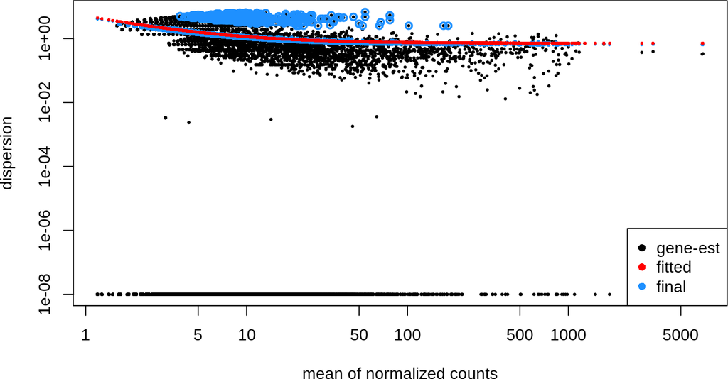

```r
plotDispEsts(ddw_param)
```

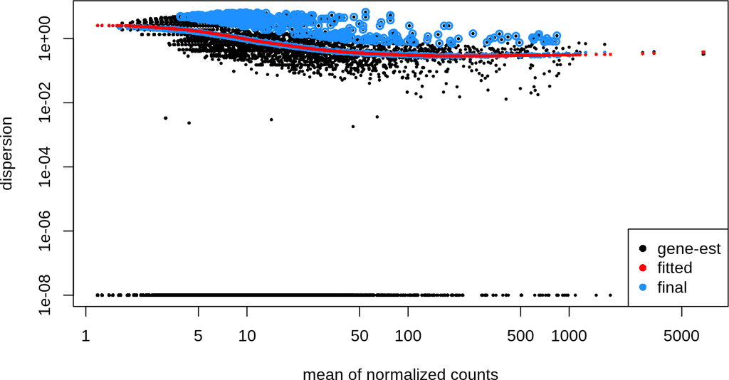

```r
plotDispEsts(ddw_local)
```

```r
parametric_resid <- na.omit(with(mcols(ddw_param),
                                 abs(log(dispGeneEst)-log(dispFit))))
local_resid <- na.omit(with(mcols(ddw_local),
                            abs(log(dispGeneEst)-log(dispFit))))
```

```r
summary(parametric_resid)
```

```
##      Min.   1st Qu.    Median      Mean   3rd Qu.      Max.
##  0.000612  0.632932 19.172591 13.050483 19.761154 19.896069
```

```r
summary(local_resid)
```

```
##      Min.   1st Qu.    Median      Mean   3rd Qu.      Max.
##  0.000115  0.550802 19.178385 12.827602 19.362438 19.376290
```

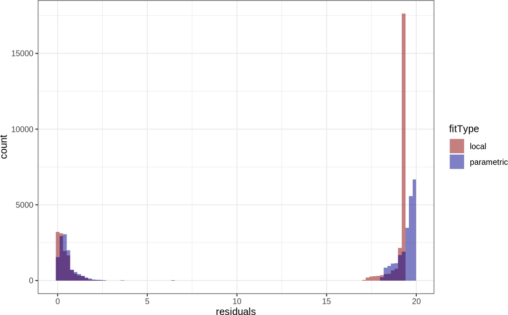

```r
resid_df <- data.frame(residuals=c(parametric_resid,local_resid),
                       fitType=c(rep("parametric",length(parametric_resid)),
                                 rep("local",length(local_resid))))
ggplot(resid_df, aes(x = residuals, fill = fitType)) +
  scale_fill_manual(values = c("darkred", "darkblue")) +
  geom_histogram(alpha = 0.5, position='identity', bins = 100) +
  theme_bw()
```

```r
ddw <- ddw_local
```

```r
if (median(local_resid) <= median(parametric_resid)){
    cat("chosen fitType: local")
    ddw <- ddw_local
  }else{
    cat("chosen fitType: parametric")
    ddw <- ddw_param
  }
```

```r
rm(ddw_local,ddw_param,resid_df,parametric_resid,local_resid)
```

## 1.7 Differential expressed windows analysis

Using LRT

```r
ddw <- nbinomLRT(ddw, full = ~type, reduced = ~1)
```

Using Wald test

```r
ddw <-  nbinomWaldTest(ddw)
```

### 1.7.1 Extract significant windows

```r
resultWindows <- resultsDEWSeq(ddw, contrast = c("type", "IP", "SMI"),
                               tidy = TRUE) %>% as_tibble
resultWindows
```

```
## # A tibble: 9,211 x 20
##    chromosome  begin    end width strand unique_id gene_id gene_name gene_type
##    <chr>       <dbl>  <int> <int> <chr>  <chr>     <chr>   <chr>     <chr>
##  1 chr1       6.30e5 6.30e5    50 +      ENSG0000… ENSG00… MTND2P28  unproces…
##  2 chr1       1.06e6 1.06e6    50 +      ENSG0000… ENSG00… AL645608… sense_in…
##  3 chr1       1.48e6 1.48e6    50 +      ENSG0000… ENSG00… ATAD3B    protein_…
##  4 chr1       1.52e6 1.52e6    50 +      ENSG0000… ENSG00… ATAD3A    protein_…
##  5 chr1       2.23e6 2.23e6    50 +      ENSG0000… ENSG00… SKI       protein_…
##  6 chr1       3.63e6 3.63e6    50 +      ENSG0000… ENSG00… TPRG1L    protein_…
##  7 chr1       6.21e6 6.21e6    50 +      ENSG0000… ENSG00… RNF207    protein_…
##  8 chr1       6.58e6 6.58e6    39 +      ENSG0000… ENSG00… ZBTB48    protein_…
##  9 chr1       1.04e7 1.04e7    50 +      ENSG0000… ENSG00… PGD       protein_…
## 10 chr1       1.05e7 1.05e7    50 +      ENSG0000… ENSG00… PEX14     protein_…
## # … with 9,201 more rows, and 11 more variables: gene_region <chr>,
## #   Nr_of_region <int>, Total_nr_of_region <int>, window_number <int>,
## #   baseMean <dbl>, log2FoldChange <dbl>, lfcSE <dbl>, stat <dbl>,
## #   pvalue <dbl>, pSlidingWindows <dbl>, pSlidingWindows.adj <dbl>
```

## 1.8 Multiple hypothesis correction

### 1.8.1 FDR correction using BH

```r
resultWindows[,'p_adj'] <- p.adjust(resultWindows$pvalue, method="BH")
```

### 1.8.2 Using IHW

```r
resultWindows[,"p_adj_IHW"] <- adj_pvalues(ihw(pvalue ~ baseMean,
                                               data = resultWindows,
                                               alpha = 0.05, nfolds = 10))
```

## 1.9 Combining windows to regions

```r
resultRegions <- extractRegions(windowRes=resultWindows, padjCol="p_adj_IHW",
                                padjThresh = 0.05,
                                log2FoldChangeThresh=1) %>% as_tibble
resultRegions
```

```
## # A tibble: 111 x 21
##    chromosome region_begin region_end strand windows_in_regi… region_length
##    <chr>             <dbl>      <int> <fct>             <dbl>         <int>
##  1 chr1          149813270  149813380 -                     4           110
##  2 chr1          149840697  149840767 -                     2            70
##  3 chr1          149842207  149842357 -                     6           150
##  4 chr1          149843440  149843533 +                     4            93
##  5 chr1          149850292  149850362 -                     2            70
##  6 chr1          149886138  149886388 -                    11           250
##  7 chr1          149886498  149886628 -                     5           130
##  8 chr1          149886974  149887024 +                     1            50
##  9 chr1          149887254  149887344 +                     3            90
## 10 chr1          149887523  149887673 -                     5           150
## # … with 101 more rows, and 15 more variables: padj_min <dbl>, padj_mean <dbl>,
## #   padj_max <dbl>, log2FoldChange_min <dbl>, log2FoldChange_mean <dbl>,
## #   log2FoldChange_max <dbl>, regionStartId <chr>, gene_id <fct>,
## #   gene_name <chr>, gene_type <chr>, gene_region <chr>, Nr_of_region <dbl>,
## #   Total_nr_of_region <dbl>, window_number <dbl>, unique_ids <chr>
```

## 1.10 Exporting results

```r
toBED(windowRes=resultWindows, regionRes=resultRegions, padjThresh=0.05,
      padjCol="p_adj_IHW", fileName="SLBP_regions_w50s20.bed")
```

## 1.11 Visualization

An R function to visualize enriched regions as volcano plots is available in [this github repo](https://github.com/EMBL-Hentze-group/DEWSeq_analysis_helpers). Please refer to README files in this repo for additional details.

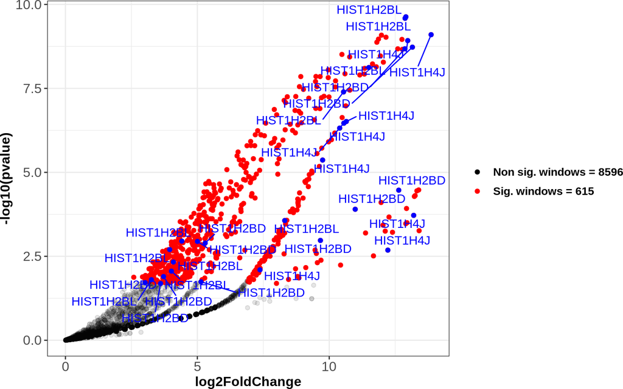

```r
fnSrc <- paste0('https://raw.githubusercontent.com/EMBL-Hentze-group/',
                'DEWSeq_analysis_helpers/master/Volcano_plot/volcanoplot.R')
source(fnSrc)
# subset of all results
tophits <- resultWindows %>% filter( p_adj_IHW<=1e-5 & log2FoldChange>=10 )%>%
                  select(gene_name,log2FoldChange) %>%
                  arrange(-log2FoldChange) %>%
                  select(gene_name) %>%
                  unlist() %>% unique()
volcanoplot(resultWindows,padj_col = 'p_adj_IHW',gene_names = tophits[c(1:3)])
```